# Linear Regression - Sales Data

BH Analytics

# Overview

The purpose of this lecture is to go over linear regression, which is the foundation of modern frequentist statistics. We will examine linear regression with a single and multiple predictors, as well as basic non-linear functions. We will consider the assumptions of linear regression, and map that to the actual statistical model we are fitting.

- Linear regression and the mean
- Adding Predictors
- Continuous Versus Categorical
- Non-linear terms
- Spline terms
- Adding interaction terms

# Different types of regression

Let’s take a moment to discuss different forms of regression. Are you familiar with any of these?

- OLS Regression, or simple linear regression
- Multiple Linear Regression
- Logistic Regression
- Generalized linear models
- Cox Time to Event Analysis
- Mixed Effects (or hierarchical)
- Repeated Measures (time series)

# General Regression Strategy

- Collect appropriate data
- Identify Outcome(s) / predictors
- Settle on a target of inference (summary statistic of outcome)
- Investigate “shape” of data
- Consider appropriate functional form (additive versus multiplicative models, distribution of outcome)
- Apply prior knowledge
- Select “best” model
- Check model for validity (residuals, etc)
- Update model
- Interpret model results
- Predict new data from model
- R has great functionality for doing all of this!

# Ordinary Least Squares Regression (Linear Modeling)

- “Basic” regression
- Easy to learn conceptually, applies to other
- Outcome is a continuous variable
- Predicting weight
- Predicting monetary values
- Predicting Lab tests
- What are the assumptions of ordinary linear regression?

# Assumptions of OLS Regression

- Assumptions *this is key*:
- Normality
- Independence
- Linearity
- Homoscedasticity (pull this off in scrabble)
- Whats all this about assumptions…If I get numbers out it, worked…

# Why care about assumptions?

- We do!
- Our tests may not be valid
- Our parameter estimates may be *biased*
- We get the wrong answer…

# Example of Regression: Predicting Sale Amount

We will learn about regression in the context of a dataset that has details on how much money customers spent, as well as other demographics about the customers.

We will begin by importing and examining the dataset:

```r
library(data.table)
library(Hmisc)
sale_df <-
  fread('Data/Data_Sims/simulated_sales_data/customer_sales1.csv')
## examine data
head(sale_df)
```

```
##    customer_id sale sale_amount region age gender activity marketing_exposure       x1        x2        x3 x4 x5 num_accounts current_customer income
## 1:      100000   No      0.0000     35  62   Male      Med                  6 73.67464  8.263063  93.87941 10  1            0               No     78
## 2:      100001  Yes    884.4780     13  71 Female     High                  5 49.19598 11.925201  72.86251  7  2            2               No     66
## 3:      100002   No      0.0000     23  53   Male     High                  6 49.86849 10.932390 128.15058 12  2            1              Yes     86
## 4:      100003   No      0.0000     12  60   Male      Med                  7 42.56315  9.725310 126.26639 11  1            0              Yes     70
## 5:      100004  Yes    243.9377     44  62   Male      Med                 11 45.03544  9.941171 108.03763  9  3            0               No     59
## 6:      100007  Yes    621.9513     42  44 Female      Low                  2 61.65991  9.152425  91.45761 10  1            1               No     60
```

```r
describe(sale_df)
```

```
## sale_df
##
##  16  Variables      8000  Observations
## --------------------------------------------------------------------------------------------------------------------------------------------------------
## customer_id
##        n  missing distinct     Info     Mean      Gmd      .05      .10      .25      .50      .75      .90      .95
##     8000        0     8000        1   104987     3329   100498   100986   102496   104989   107472   108984   109481
##
## lowest : 100000 100001 100002 100003 100004, highest: 109995 109996 109997 109998 109999
## --------------------------------------------------------------------------------------------------------------------------------------------------------
## sale
##        n  missing distinct
##     8000        0        2
##
## Value         No   Yes
## Frequency   3235  4765
## Proportion 0.404 0.596
## --------------------------------------------------------------------------------------------------------------------------------------------------------
## sale_amount
##        n  missing distinct     Info     Mean      Gmd      .05      .10      .25      .50      .75      .90      .95
##     8000        0     4737    0.934      249    320.3      0.0      0.0      0.0    118.8    418.9    697.9    875.1
##
## lowest :    0.000   10.000   10.000   10.000   10.000, highest: 1834.651 1881.856 1927.765 2075.270 2111.991
## --------------------------------------------------------------------------------------------------------------------------------------------------------
## region
##        n  missing distinct     Info     Mean      Gmd      .05      .10      .25      .50      .75      .90      .95
##     8000        0       50        1    25.42    16.64        3        5       13       26       38       45       48
##
## lowest :  1  2  3  4  5, highest: 46 47 48 49 50
## --------------------------------------------------------------------------------------------------------------------------------------------------------
## age
##        n  missing distinct     Info     Mean      Gmd      .05      .10      .25      .50      .75      .90      .95
##     8000        0       77    0.999    59.13    12.67       41       45       51       59       67       74       78
##
## lowest :  21  22  23  25  26, highest:  94  95  97  98 100
## --------------------------------------------------------------------------------------------------------------------------------------------------------
## gender
##        n  missing distinct
##     8000        0        2
##
```

[output cut: 65 more lines]

```
## --------------------------------------------------------------------------------------------------------------------------------------------------------
## current_customer
##        n  missing distinct
##     8000        0        2
##
## Value         No   Yes
## Frequency   5647  2353
## Proportion 0.706 0.294
## --------------------------------------------------------------------------------------------------------------------------------------------------------
## income
##        n  missing distinct     Info     Mean      Gmd      .05      .10      .25      .50      .75      .90      .95
##     8000        0       71    0.999    64.79    11.21       49       52       58       65       71       78       81
##
## lowest :  26  31  32  33  34, highest:  96  98 101 102 103
## --------------------------------------------------------------------------------------------------------------------------------------------------------
```

We will focus on the outcome of `sale_amount`.

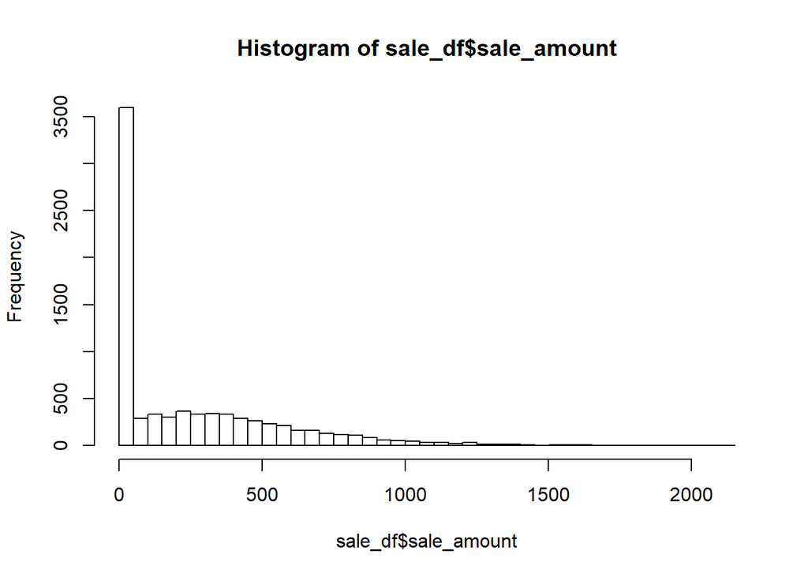

```r
## Examine distribution
hist(sale_df$sale_amount,50)
```

Notice that sale amount has a large mass at zero. I am going to focus on the customers who bought something (i.e. have sale amount > 0) for this analysis:

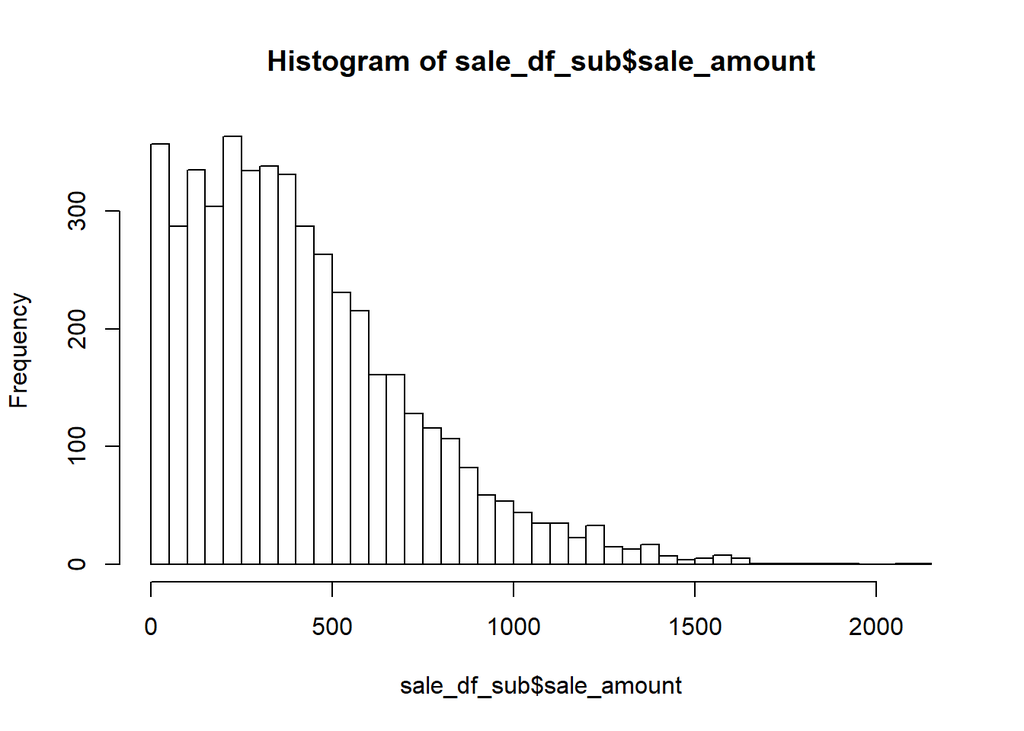

```r
## Subset to rows with sales > 0
sale_df_sub <-
  sale_df[sale_amount > 0]
## check distribution
hist(sale_df_sub$sale_amount,50)
```

# Summarizing a continuous distribution

Now we must pick a statistical summary to ‘target’ for this distribution. What summary should we use to ‘describe’ `sale_amount`?

There are actually a few options…the mean, the median, something else…

In normal linear modeling, we always are estimating the mean (even if you wanted to focus on something else…). If you want to estimate something other than the mean, you must use something other than normal linear regression (like quantile regression)!

```r
## calculate mean (center) and the standard deviation (spread) of the data
sale_df_sub[,list(mean_sales = mean(sale_amount),
                  sd_sales = sd(sale_amount))]
```

```
##    mean_sales sd_sales
## 1:   418.0103 308.5484
```

# First Linear Model: Null model

There is a direct parallel to what we just did in linear modeling. We can fit the intercept only model, or the “null” model and we will estimate the sample mean.

Here is the actual model we are fitting:

$$mean(sale\_amount)=\beta_0 + e$$

$$\overline{sale\_amount}=\beta_0 + e$$

Where $e$ is the error term that is normally distributed with mean=0 and variance = $\sigma^2$

So we are asking R to fit a model with 2 parameters, and R will estimate those parameters.

```r
## fit model
mod0 <-
  lm(sale_amount ~ 1,
     data = sale_df_sub)
## check results
summary(mod0)
```

```
##
## Call:
## lm(formula = sale_amount ~ 1, data = sale_df_sub)
##
## Residuals:
##     Min      1Q  Median      3Q     Max
## -408.01 -232.78  -60.12  164.18 1693.98
##
## Coefficients:
##             Estimate Std. Error t value Pr(>|t|)
## (Intercept)   418.01       4.47   93.52   <2e-16 ***
## ---
## Signif. codes:  0 '***' 0.001 '**' 0.01 '*' 0.05 '.' 0.1 ' ' 1
##
## Residual standard error: 308.5 on 4764 degrees of freedom
```

# Exercise on your own:

- Import the “Leinhardt” data from the ‘carData’ package.
- We will use this data for some regression based tasks.
- Check the help for the dataset to understand it
- The outcome of interest is ‘infant’ (the infant mortality rate)

Questions:

- After importing the data, calculate the mean/standard deviation of the outcome
- Using a linear model, fit the ‘intercept only model’ and interpret the output. Can you see the mean?
- Does the standard error in the linear model output match the standard deviation you calculated? Why not?

```r
## Uncomment this section to import the data and check the help
# library(carData)
# data("Leinhardt")
# ?Leinhardt
```

# Model: Single predictor

Our second model will include a single categorical predictor. In this case we will use gender as a predictor and see if mean sale_amount depends on gender. We could start by doing this using grouped analysis:

```r
## sales grouped by gender
sale_df_sub[,list(mean_sales = mean(sale_amount),
                  sd_sales = sd(sale_amount)),
            by=gender]
```

```
##    gender mean_sales sd_sales
## 1: Female   580.8623  311.809
## 2:   Male   295.4670  242.341
```

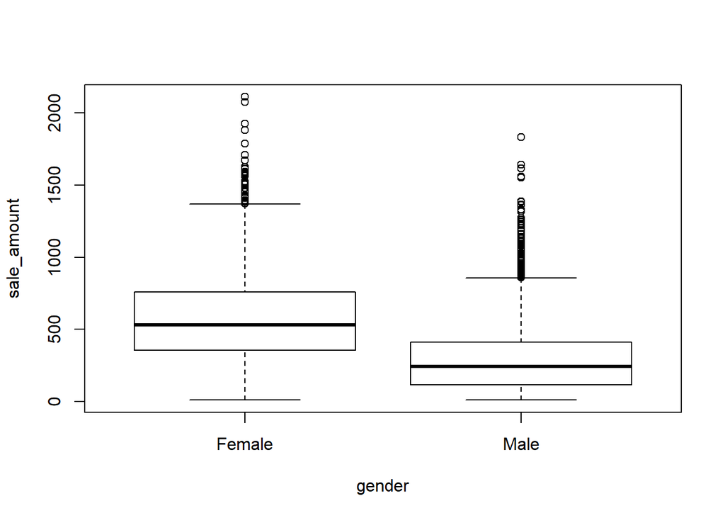

```r
## Create plot
boxplot(sale_amount ~ gender,
        data = sale_df_sub)
```

There seems to be a difference in sale_amount for the different genders. We can fit a linear model that includes this as a predictor to get a statistical test. The model we are fitting looks like this:

$$\overline{sale}=\beta_0 + \beta_{gender}*(gender) + e$$

The intercept is implied in this model, so we do not need to include the + 1.

```r
## fit model
mod1 <-
  lm(sale_amount ~ gender,
     data = sale_df_sub)
## check results
summary(mod1)
```

```
##
## Call:
## lm(formula = sale_amount ~ gender, data = sale_df_sub)
##
## Residuals:
##     Min      1Q  Median      3Q     Max
## -570.86 -196.82  -51.12  144.67 1539.18
##
## Coefficients:
##             Estimate Std. Error t value Pr(>|t|)
## (Intercept)  580.862      6.065   95.78   <2e-16 ***
## genderMale  -285.395      8.029  -35.55   <2e-16 ***
## ---
## Signif. codes:  0 '***' 0.001 '**' 0.01 '*' 0.05 '.' 0.1 ' ' 1
##
## Residual standard error: 274.3 on 4763 degrees of freedom
## Multiple R-squared:  0.2097, Adjusted R-squared:  0.2095
## F-statistic:  1264 on 1 and 4763 DF,  p-value: < 2.2e-16
```

Can you look at the parameter estimate, and figure out what the coefficients mean?

Here is the model equation with the parameter estimates:

$$\overline{sale\_amount}=580.9 - 285.4*(gender) + e$$

There seems to be a difference in sale amount by gender. However, is this difference statistically significant? What null hypothesis is the p-value associated with this parameter testing?

If there were no difference, then $\beta_{gender}$ would be equal to 0. So the null hypothesis is:

$\beta_{gender} = 0$

The p-value is quite small, so we reject this null hypothesis as unlikely given the data, and conclude that $\beta_{gender}$ is not equal to 0.

Note we can change the reference level by changing the order of the factor:

```r
## can change the default reference level based on factor order
sale_df_sub$gender_2 <-
  factor(sale_df_sub$gender,
         levels = c('Male','Female'))
## fit model
mod1 <-
  lm(sale_amount ~ gender_2,
     data = sale_df_sub)
## check results
summary(mod1)
```

```
##
## Call:
## lm(formula = sale_amount ~ gender_2, data = sale_df_sub)
##
## Residuals:
##     Min      1Q  Median      3Q     Max
## -570.86 -196.82  -51.12  144.67 1539.18
##
## Coefficients:
##                Estimate Std. Error t value Pr(>|t|)
## (Intercept)     295.467      5.261   56.16   <2e-16 ***
## gender_2Female  285.395      8.029   35.55   <2e-16 ***
## ---
## Signif. codes:  0 '***' 0.001 '**' 0.01 '*' 0.05 '.' 0.1 ' ' 1
##
## Residual standard error: 274.3 on 4763 degrees of freedom
## Multiple R-squared:  0.2097, Adjusted R-squared:  0.2095
## F-statistic:  1264 on 1 and 4763 DF,  p-value: < 2.2e-16
```

# Exercise on your own:

- Using the “Leinhardt” data from the ‘carData’ package, replicate the model we just fit above by doing following;
- Calculate the mean / standard deviation of infant mortality rate for oil == yes and oil == no
- Is the standard deviation of infant mortality rate similar between oil == yes and oil == no? What linear model assumption does this map to?
- Fit the linear model with oil as a single predictor and interpret the output. How does this output connect to the mean by oil?

```r
## Uncomment this section to import the data and check the help
# library(carData)
# data("Leinhardt")
# ?Leinhardt
```

# A word about formula’s in R

`model <- lm(formula, data)`

- Formula is a special object in R

`response variable ~ explanatory variable(s)`

`Y ~ X1 + X2 + X3 + X4...`

# Formula syntax

| op |  | description |
| --- | --- | --- |
| `+` | `+ x` | include this variable |
| `-` | `- x` | delete this variable |
| `:` | `x:z` | include interaction |
| `*` | `x*z` | include interaction and lower |
| `I` | `I(x*z)` | Resolve expression before model |
| `1` | `- 1` | intercept: delete the intercept |

# Model: Categorical predictor with more than 2 levels

What is our categorical predictor has more than two levels? Number of accounts has 5 possible values in this dataset. We may wish to understand how mean `sale_amount` varies by the number of accounts. Here are some non-modelling approached to doing this:

```r
## describe number of accounts
describe(sale_df_sub$num_accounts)
```

```
## sale_df_sub$num_accounts
##        n  missing distinct     Info     Mean      Gmd
##     4765        0        5    0.746   0.4938   0.6662
##
## lowest : 0 1 2 3 4, highest: 0 1 2 3 4
##
## Value          0     1     2     3     4
## Frequency   2902  1443   359    52     9
## Proportion 0.609 0.303 0.075 0.011 0.002
```

```r
unique(sale_df_sub$num_accounts)
```

```
## [1] 2 0 1 3 4
```

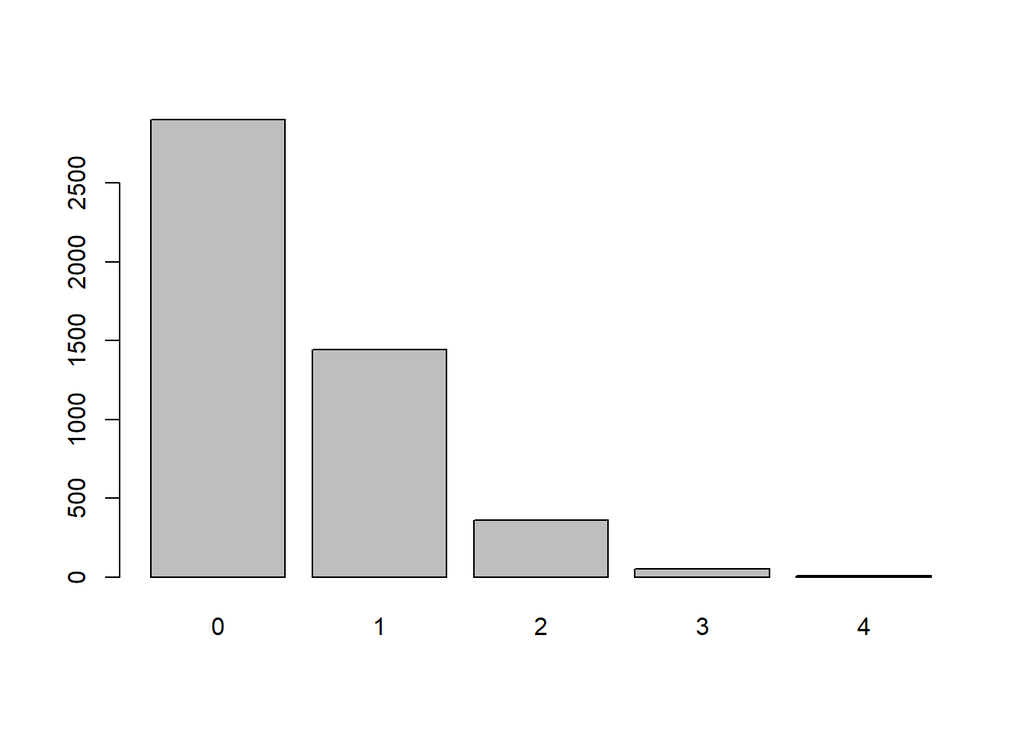

```r
barplot(table(sale_df_sub$num_accounts))
```

```r
## Check average sale amount per account
sale_df_sub[,list(mean_sales = mean(sale_amount),
                  sd_sales = sd(sale_amount)),
            by=num_accounts]
```

```
##    num_accounts mean_sales sd_sales
## 1:            2   426.0214 317.9426
## 2:            0   417.3728 308.2400
## 3:            1   415.4100 307.7368
## 4:            3   446.4696 270.1237
## 5:            4   556.5036 386.3028
```

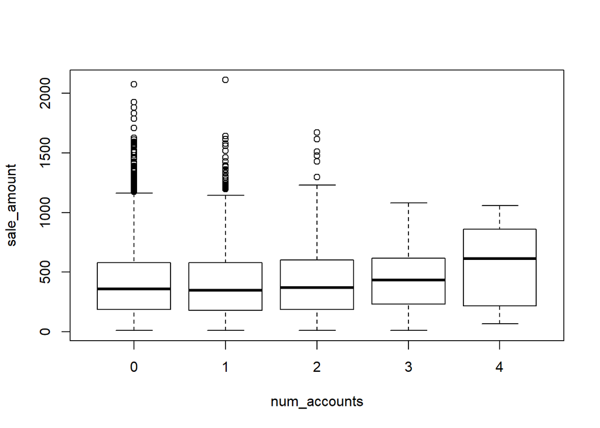

```r
## Create plot
boxplot(sale_amount ~ num_accounts,
        data = sale_df_sub)
```

It looks like number of accounts may be associated with sale_amount in this data, but maybe not?

Let’s fit a regression model to further investigate this relationship. Here is our new model equation:

$$\overline{sale\_amount}=\beta_0 + \beta_{n\_accounts1}*(n\_accounts1==1) + \beta_{n\_accounts2}*(n\_accounts2==2) + \beta_{n\_accounts3}*(n\_accounts3==3) +
\beta_{n\_accounts4}*(n\_accounts4==4) + e$$

Why did I not include a term for n_accounts=0?

Because it is absorbed into the intercept.

Here is the code to actually fit the model:

```r
## fit model
mod2 <-
  lm(sale_amount ~ factor(num_accounts),
     data = sale_df_sub)
## check results
summary(mod2)
```

```
##
## Call:
## lm(formula = sale_amount ~ factor(num_accounts), data = sale_df_sub)
##
## Residuals:
##     Min      1Q  Median      3Q     Max
## -488.05 -232.59  -59.59  164.56 1696.58
##
## Coefficients:
##                       Estimate Std. Error t value Pr(>|t|)
## (Intercept)            417.373      5.728  72.860   <2e-16 ***
## factor(num_accounts)1   -1.963      9.940  -0.197    0.843
## factor(num_accounts)2    8.649     17.265   0.501    0.616
## factor(num_accounts)3   29.097     43.176   0.674    0.500
## factor(num_accounts)4  139.131    103.024   1.350    0.177
## ---
## Signif. codes:  0 '***' 0.001 '**' 0.01 '*' 0.05 '.' 0.1 ' ' 1
##
## Residual standard error: 308.6 on 4760 degrees of freedom
## Multiple R-squared:  0.0005484,  Adjusted R-squared:  -0.0002915
## F-statistic: 0.6529 on 4 and 4760 DF,  p-value: 0.6248
```

Here is the model with the parameters:

$$\overline{sale\_amount}=417.4 - 1.9*(n\_accounts1==1) + 8.6*(n\_accounts2==2) +
29.1*(n\_accounts3==3) + 139.1*(n\_accounts4==4) + e$$

What is the expected value of sale amount for a customer with 2 accounts under this model?

$$\overline{sale\_amount}=417.4 - 1.9*(0) + 8.6*(1) +
29.1*(0) + 139.1*(0)$$

# P-values from discrete predictors with more than 2 levels

Which p-value do we interpret?

When we include a factor with multiple levels, we should interpret the ‘overall’ p-value. This is not printed by default.

```r
## Test the factor 'all at once'
anova(mod2)
```

```
## Analysis of Variance Table
##
## Response: sale_amount
##                        Df    Sum Sq Mean Sq F value Pr(>F)
## factor(num_accounts)    4    248716   62179  0.6529 0.6248
## Residuals            4760 453294200   95230
```

```r
## can think of it as comparing this fit to the null model
anova(mod0,mod2)
```

```
## Analysis of Variance Table
##
## Model 1: sale_amount ~ 1
## Model 2: sale_amount ~ factor(num_accounts)
##   Res.Df       RSS Df Sum of Sq      F Pr(>F)
## 1   4764 453542917
## 2   4760 453294200  4    248716 0.6529 0.6248
```

# Discrete versus continuous

What if I did not include the factor() in my model formula? In that case, I would be treating number of accounts as a numeric variable.

```r
## fit model
mod3 <-
  lm(sale_amount ~ num_accounts,
     data = sale_df_sub)
## check results
summary(mod3)
```

```
##
## Call:
## lm(formula = sale_amount ~ num_accounts, data = sale_df_sub)
##
## Residuals:
##     Min      1Q  Median      3Q     Max
## -420.30 -231.73  -60.16  164.66 1691.50
##
## Coefficients:
##              Estimate Std. Error t value Pr(>|t|)
## (Intercept)   415.588      5.473  75.940   <2e-16 ***
## num_accounts    4.905      6.394   0.767    0.443
## ---
## Signif. codes:  0 '***' 0.001 '**' 0.01 '*' 0.05 '.' 0.1 ' ' 1
##
## Residual standard error: 308.6 on 4763 degrees of freedom
## Multiple R-squared:  0.0001236,  Adjusted R-squared:  -8.635e-05
## F-statistic: 0.5887 on 1 and 4763 DF,  p-value: 0.443
```

What is the model that I just fit?

$$\overline{sale\_amount}=\beta_0 + \beta_{n\_accounts}*(n\_accounts) + e$$

What is my prediction of sale amount for a customer with 2 accounts?

$$\overline{sale\_amount}=415.6 + 4.9*(2)$$

```r
415.6 + 4.9*(2)
```

```
## [1] 425.4
```

This is equivalent to fitting a straight line:

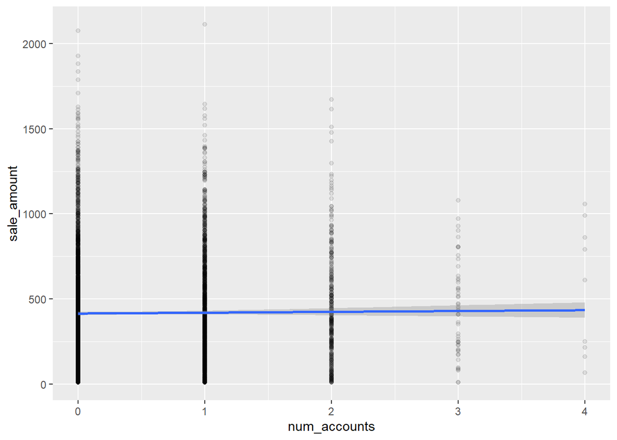

```r
## create plot
library(ggplot2)
ggplot(sale_df_sub,aes(x=num_accounts,y=sale_amount)) +
  geom_point(alpha=0.1) +
  geom_smooth(method='lm')
```

# Model: Continuous Predictor

What about using a continuous predictor in the equation? This is similar to doing a correlation, but not exactly. Let’s assume there is a linear relationship between age and sale amount. Here is a figure demonstrating that relationship:

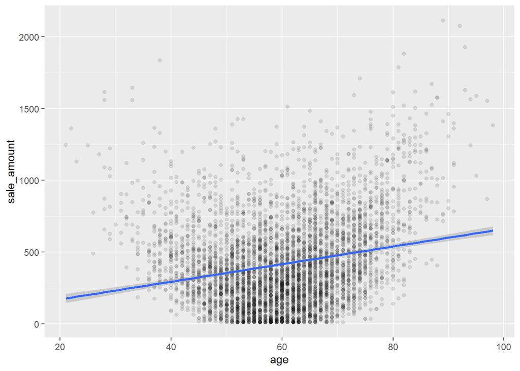

```r
## create plot
library(ggplot2)
ggplot(sale_df_sub,aes(x=age,y=sale_amount)) +
  geom_point(alpha=0.1) +
  geom_smooth(method='lm')
```

This looks like a reasonable fit, although we will look at a non-linear fit next. There is a possible non-linear relationship, but more on that in a moment.

The regression model we will fit for this data looks like this:

$$\overline{sale\_amount}=\beta_0 + \beta_{age}*(age) + e$$

We are assuming a linear trend of age on sale amount with this model. We can fit it easily like so:

```r
## fit model
mod4 <-
  lm(sale_amount ~ age,
     data = sale_df_sub)
## check results
summary(mod4)
```

```
##
## Call:
## lm(formula = sale_amount ~ age, data = sale_df_sub)
##
## Residuals:
##     Min      1Q  Median      3Q     Max
## -479.50 -228.51  -54.16  164.78 1552.38
##
## Coefficients:
##             Estimate Std. Error t value Pr(>|t|)
## (Intercept)   49.252     23.858   2.064    0.039 *
## age            6.132      0.390  15.721   <2e-16 ***
## ---
## Signif. codes:  0 '***' 0.001 '**' 0.01 '*' 0.05 '.' 0.1 ' ' 1
##
## Residual standard error: 300.9 on 4763 degrees of freedom
## Multiple R-squared:  0.04933,    Adjusted R-squared:  0.04913
## F-statistic: 247.2 on 1 and 4763 DF,  p-value: < 2.2e-16
```

Here is the model with the estimated parameters:

$$\overline{sale\_amount}=49.25 + 6.13*(age) + e$$

```r
mean(sale_df_sub$sale_amount)
```

```
## [1] 418.0103
```

So for a person aged 60, our predicted sale_amount would be:

$$\overline{sale\_amount}=49.25 + 6.13*(60) + e$$

```r
49.25 + 6.13*(60)
```

```
## [1] 417.05
```

And for a person with age = 30, our predicted mpg would be:

$$\overline{sale\_amount}=49.25 + 6.13*(30) + e$$

```r
49.25 + 6.13*(30)
```

```
## [1] 233.15
```

# Exercise on your own:

- Continue to use the “Leinhardt” data from the ‘carData’ package

Questions:

- Create a scatterplot between income and infant - does this look like a linear relationship?
- Fit a linear model with infant as the outcome and income as the predictor. Interpret the parameter estimate - is it statistically significant?

# Thinking about ‘model errors’

let’s look at the linear fit for age again -

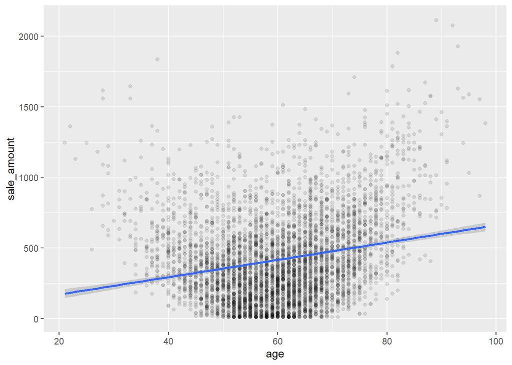

```r
## create plot
library(ggplot2)
ggplot(sale_df_sub,aes(x=age,y=sale_amount)) +
  geom_point(alpha=0.1) +
  geom_smooth(method='lm')
```

If we were to calculate the ‘error’ for every dot on this plot, that would mean calculate the difference between the dot (the observed valued) and the prediction (the line on the graph).

We call these calculations ‘residuals’ - that is the difference between our prediction (based on the model), and the actual real value. In this case, there is a pattern to the residuals. Do you see that we tend to under predict sales for young and old people, although we over predict sales for middle aged people in our data? We can visualize that by plotting the residuals against age:

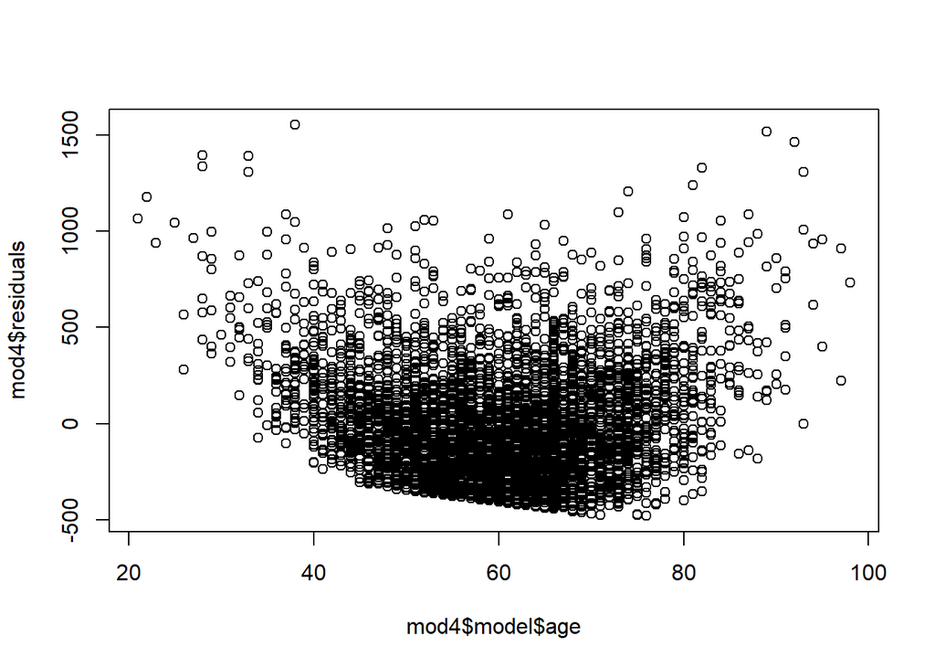

```r
plot(mod4$model$age,mod4$residuals)
```

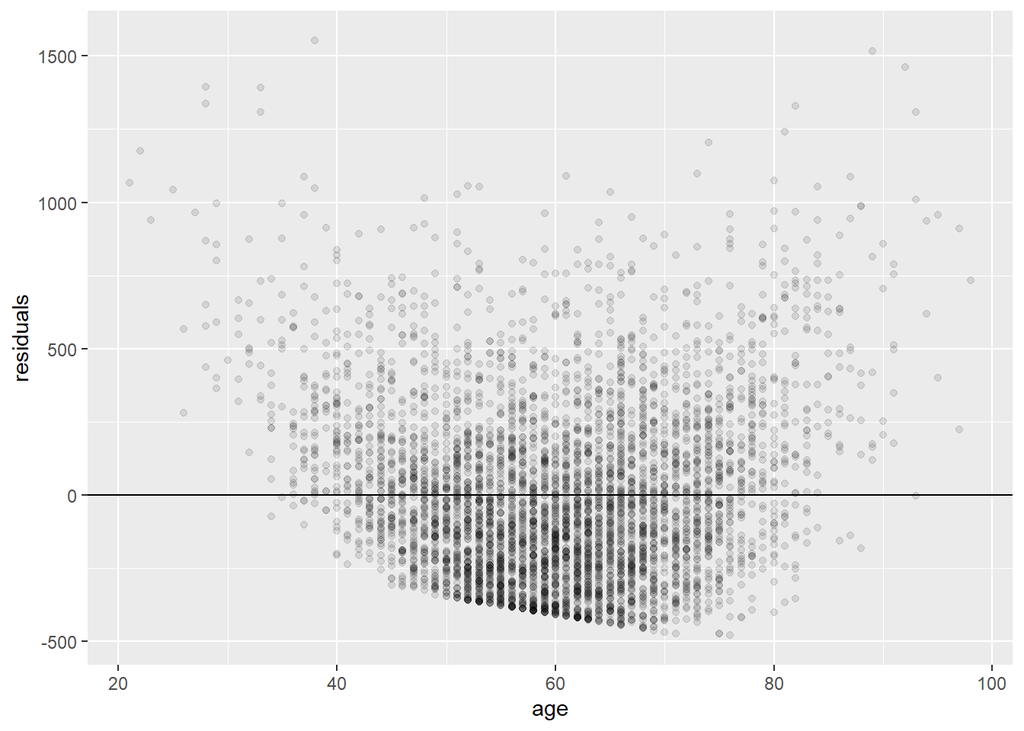

```r
## use ggplot instead!
df_new <-
  data.frame(residuals=mod4$residuals,
             age=mod4$model$age)
ggplot(df_new,aes(x=age,y=residuals)) +
  geom_point(alpha=0.1) +
  geom_hline(yintercept = 0)
```

If the model fit well, what would you expect these residuals to look like?

Let’s try a polynomial regression to improve the model fit.

# Model: Polynomial regression

It looks like the assumption of linearity may be untrue for age. Perhaps a non-linear function would provide a better fit of the data?

```r
## fit model
mod5 <-
  lm(sale_amount ~ age + I(age**2),
     data = sale_df_sub)
## check results
summary(mod5)
```

```
##
## Call:
## lm(formula = sale_amount ~ age + I(age^2), data = sale_df_sub)
##
## Residuals:
##     Min      1Q  Median      3Q     Max
## -744.55 -201.00  -45.11  148.18 1268.51
##
## Coefficients:
##              Estimate Std. Error t value Pr(>|t|)
## (Intercept) 2763.6188    80.3825   34.38   <2e-16 ***
## age          -87.3703     2.6928  -32.45   <2e-16 ***
## I(age^2)       0.7774     0.0222   35.02   <2e-16 ***
## ---
## Signif. codes:  0 '***' 0.001 '**' 0.01 '*' 0.05 '.' 0.1 ' ' 1
##
## Residual standard error: 268.3 on 4762 degrees of freedom
## Multiple R-squared:  0.244,  Adjusted R-squared:  0.2437
## F-statistic: 768.5 on 2 and 4762 DF,  p-value: < 2.2e-16
```

```r
## compare against null model
anova(mod0,mod5)
```

```
## Analysis of Variance Table
##
## Model 1: sale_amount ~ 1
## Model 2: sale_amount ~ age + I(age^2)
##   Res.Df       RSS Df Sum of Sq      F    Pr(>F)
## 1   4764 453542917
## 2   4762 342878641  2 110664276 768.47 < 2.2e-16 ***
## ---
## Signif. codes:  0 '***' 0.001 '**' 0.01 '*' 0.05 '.' 0.1 ' ' 1
```

```r
## compare against only the linear term
anova(mod4,mod5)
```

```
## Analysis of Variance Table
##
## Model 1: sale_amount ~ age
## Model 2: sale_amount ~ age + I(age^2)
##   Res.Df       RSS Df Sum of Sq      F    Pr(>F)
## 1   4763 431168936
## 2   4762 342878641  1  88290295 1226.2 < 2.2e-16 ***
## ---
## Signif. codes:  0 '***' 0.001 '**' 0.01 '*' 0.05 '.' 0.1 ' ' 1
```

How can we visualize the predictions from this model? We can create a new dataframe with the predictions:

```r
quantile(sale_df_sub$age)
```

```
##   0%  25%  50%  75% 100%
##   21   53   60   68   98
```

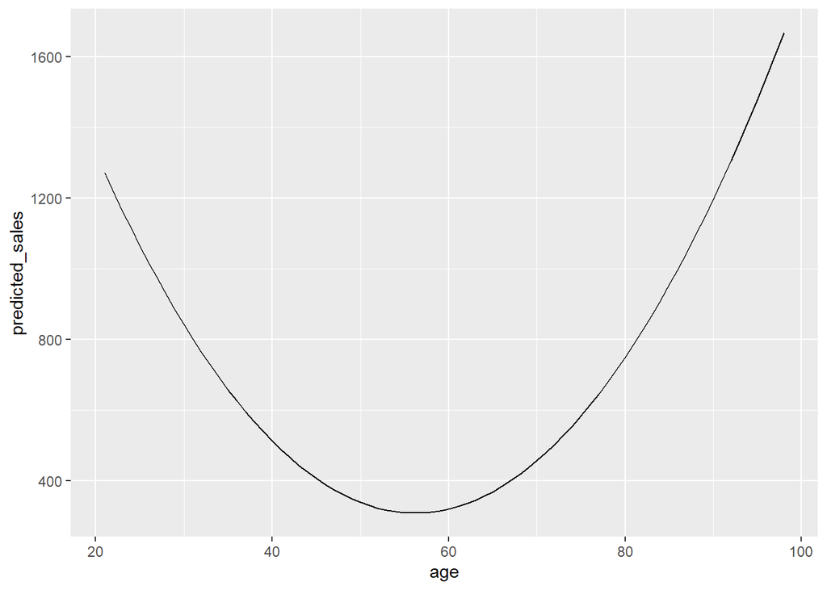

```r
pred_df <-
  data.frame(age = seq(21,98,1))
## use predict method to get prediction for each age
pred_df$predicted_sales <-
  predict(mod5,newdata = pred_df)
## now we can plot
ggplot(pred_df,aes(age,predicted_sales)) +
  geom_line()
```

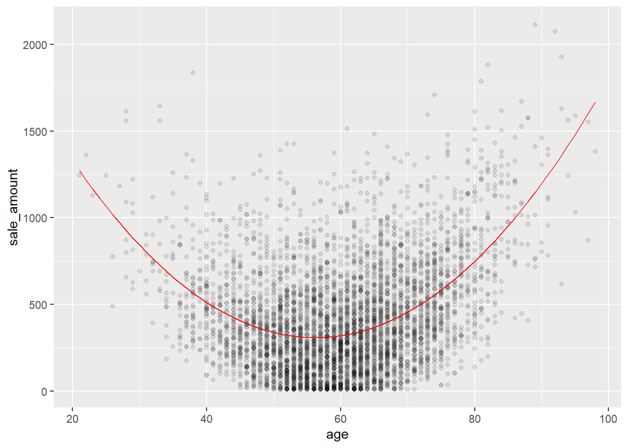

```r
## add the old data
ggplot(sale_df_sub,aes(x=age,y=sale_amount)) +
  geom_point(alpha=0.1) +
geom_line(data=pred_df,color='red',
          aes(age,predicted_sales))
```

Does that look like a better fit? Let’s check the residuals for a pattern!

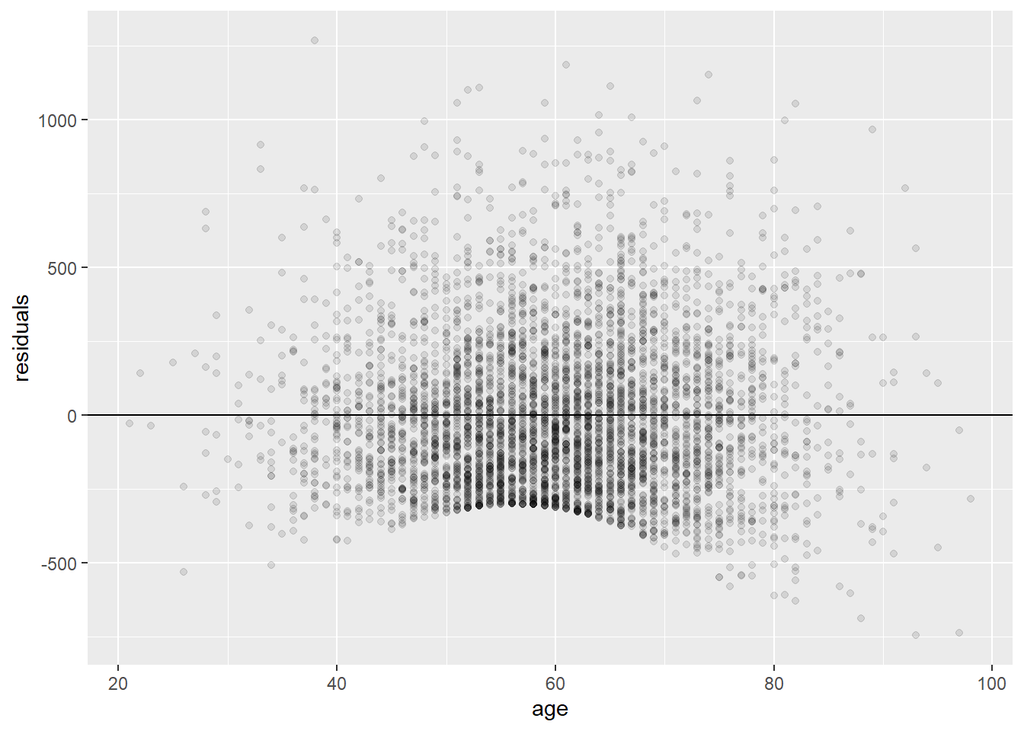

```r
df_new <-
  data.frame(residuals=mod5$residuals,
             age=mod5$model$age)
ggplot(df_new,aes(x=age,y=residuals)) +
  geom_point(alpha=0.1) +
  geom_hline(yintercept = 0)
```

# Model: Multiple parameters

We can include both categorical and continuous predictors in our model. Can you interpret the following model fit and output?

$$\overline{sale\_amount}=\beta_{int} + \beta_{age}*(age) + \beta_{age2}*(age^2) + \beta_{male}*(gender == male) + \beta_{num\_accounts}*(num\_accounts) + e$$

```r
## fit model
mod6 <-
  lm(sale_amount ~ age + I(age**2) + gender + num_accounts,
     data = sale_df_sub)
## check results
summary(mod6)
```

```
##
## Call:
## lm(formula = sale_amount ~ age + I(age^2) + gender + num_accounts,
##     data = sale_df_sub)
##
## Residuals:
##     Min      1Q  Median      3Q     Max
## -711.51 -168.29  -37.66  124.07 1284.00
##
## Coefficients:
##                Estimate Std. Error t value Pr(>|t|)
## (Intercept)  3137.65449   72.89150  43.046   <2e-16 ***
## age           -89.79127    2.41087 -37.244   <2e-16 ***
## I(age^2)        0.75638    0.01988  38.057   <2e-16 ***
## genderMale   -267.15118    7.74234 -34.505   <2e-16 ***
## num_accounts    5.45384    4.97845   1.095    0.273
## ---
## Signif. codes:  0 '***' 0.001 '**' 0.01 '*' 0.05 '.' 0.1 ' ' 1
##
## Residual standard error: 240 on 4760 degrees of freedom
## Multiple R-squared:  0.3953, Adjusted R-squared:  0.3948
## F-statistic: 777.9 on 4 and 4760 DF,  p-value: < 2.2e-16
```

The interpretation of any individual model parameter estimated here is ‘conditional on the other model parameters’. You might also here people say, ‘after adjusting for …we find the relationship between X and Y is this’.

So what to conclude from the p-values? Num_accounts has a high p-value here. We may conclude that num_accounts is not a good predictor of the outcome, and remove it from the model. We should note that variable selection into your model is usually more complex than this! We will cover variable selection more completely in a subsequent lecture.

# Exercise on your own:

- Continue to use the “Leinhardt” data from the ‘carData’ package

Questions:

- Fit a linear model with infant as the outcome and some combination of the other variables as predictors. Practice interpreting the parameter estimates.

# Focus on Marketing Exposure

Now that we understand how linear models work in general, let’s focus on the marketing exposure variable. This variable indicates how much exposure a person has to a newly test marketing campaign. We wish to understand if the marketing campaign was effective. We presume people with more exposure were more likely to spend more money. We will investigate this hypothesis using this dataset.

We may start by looking at the overall relationship between marketing exposure and sale_amount:

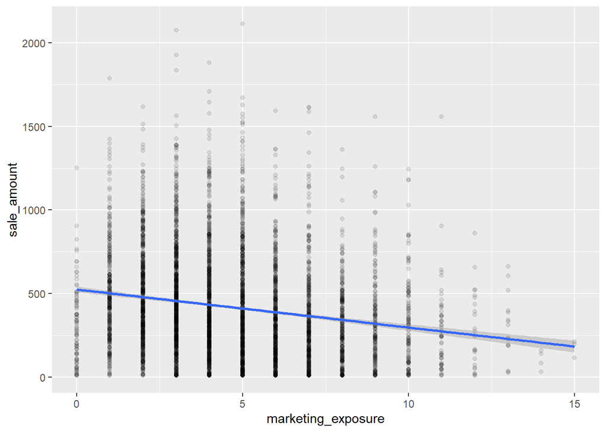

```r
## create plot
library(ggplot2)
ggplot(sale_df_sub,aes(x=marketing_exposure,y=sale_amount)) +
  geom_point(alpha=0.1) +
  geom_smooth(method='lm')
```

This is disappointing (and odd)! It looks like the more marketing exposure one receives, the less likely they are to spend more money!! Here is the linear model:

```r
## fit model
mod7 <-
  lm(sale_amount ~ marketing_exposure,
     data = sale_df_sub)
## check results
summary(mod7)
```

```
##
## Call:
## lm(formula = sale_amount ~ marketing_exposure, data = sale_df_sub)
##
## Residuals:
##     Min      1Q  Median      3Q     Max
## -514.80 -225.71  -57.87  160.25 1700.64
##
## Coefficients:
##                    Estimate Std. Error t value Pr(>|t|)
## (Intercept)         524.796      9.118   57.55   <2e-16 ***
## marketing_exposure  -22.689      1.698  -13.36   <2e-16 ***
## ---
## Signif. codes:  0 '***' 0.001 '**' 0.01 '*' 0.05 '.' 0.1 ' ' 1
##
## Residual standard error: 303 on 4763 degrees of freedom
## Multiple R-squared:  0.03612,    Adjusted R-squared:  0.03592
## F-statistic: 178.5 on 1 and 4763 DF,  p-value: < 2.2e-16
```

The p-value is quite low, so it looks like we might conclude that marketing exposure is negatively associated with the outcome. That doesn’t make sense, what is going on? Perhaps we need a non-linear term? More on that in a moment. Let’s first introduce the idea of a ‘confounder’

# Confounding variables

Confounding occurs when a variable that is associated with both the primary exposure and the outcome causes a spurious association to be found. You can check wiki for a bit more information: [wiki link](https://en.wikipedia.org/wiki/Confounding)

What does that mean exactly? Let’s think about two different examples to solidify this idea.

What if we were interested in understanding the association between consuming ice cream and being bitten by a shark. If we had a bunch of data on ice cream consumption as well as shark attacks, we might find that people who eat ice cream are more likely to subsequently be bitten by a shark! Would we then conclude that ice cream causes shark attacks? If we were to reduce ice cream consumption, we would also reduce shark attacks?

This is a silly example of course. The problem is not ice cream consumption. What is actually happening is that in the summer time when people are by the beach, they eat more ice cream. Additionally, people at the beach in the summer are more likely to be bitten by a shark because they are swimming. In this example, we would call ‘summertime at the beach’ the confounder. Since it is associated with both ice cream consumption and with shark attacks, we might accidentally conclude those variables are related if we forget to consider ‘summertime at the beach’.

Let’s think about another example, slightly less silly. Does coffee consumption increase your risk of developing lung cancer? We could try to answer this question by looking at a bunch of data on coffee consumption and subsequent lung cancer. If you were to find that people who drink more coffee also have a higher risk of developing lung cancer in the dataset, would you conclude that coffee does indeed cause lung cancer? Why or why not?

What if people who smoke are also more likely to consume coffee (coffee and cigarettes for breakfast). We know that smoking is also related to lung cancer. In this case, smoking is the ‘confounder’ which is causing a spurious association between coffee and lung cancer.

# Non-Linear fits

We can try a flexible fit with ggplot and the ‘loess’ method (locally weighted regression):

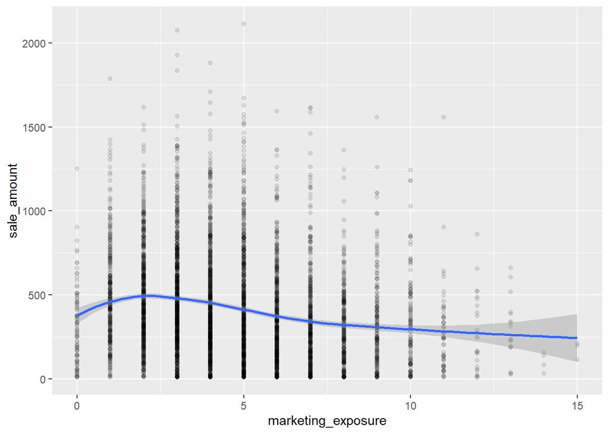

```r
## create plot
library(ggplot2)
ggplot(sale_df_sub,aes(x=marketing_exposure,y=sale_amount)) +
  geom_point(alpha=0.1) +
  geom_smooth(method = 'loess')
```

This is still a bit hard to understand. Perhaps there is a gender effect as well?

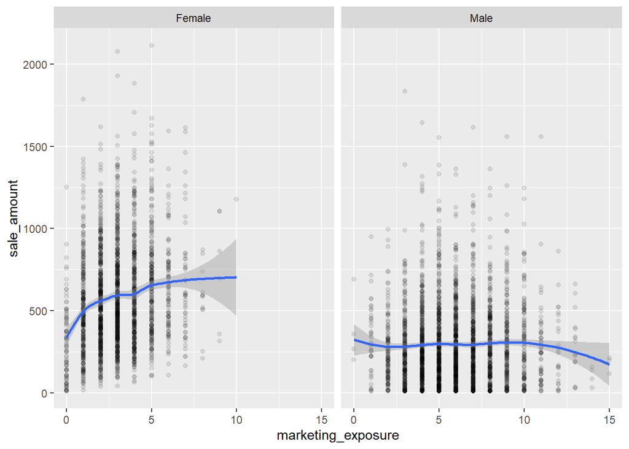

```r
## create plot
library(ggplot2)
ggplot(sale_df_sub,aes(x=marketing_exposure,y=sale_amount)) +
  geom_point(alpha=0.1) +
  geom_smooth(method = 'loess') +
  facet_wrap(~gender)
```

```r
## fit model
mod8 <-
  lm(sale_amount ~ marketing_exposure*gender,
     data = sale_df_sub)
## check results
summary(mod8)
```

```
##
## Call:
## lm(formula = sale_amount ~ marketing_exposure * gender, data = sale_df_sub)
##
## Residuals:
##     Min      1Q  Median      3Q     Max
## -582.07 -196.21  -49.74  137.66 1545.06
##
## Coefficients:
##                               Estimate Std. Error t value Pr(>|t|)
## (Intercept)                    467.856     12.400  37.729   <2e-16 ***
## marketing_exposure              37.095      3.563  10.412   <2e-16 ***
## genderMale                    -184.235     18.507  -9.955   <2e-16 ***
## marketing_exposure:genderMale  -35.106      4.153  -8.452   <2e-16 ***
## ---
## Signif. codes:  0 '***' 0.001 '**' 0.01 '*' 0.05 '.' 0.1 ' ' 1
##
## Residual standard error: 271.3 on 4761 degrees of freedom
## Multiple R-squared:  0.2274, Adjusted R-squared:  0.2269
## F-statistic: 467.1 on 3 and 4761 DF,  p-value: < 2.2e-16
```

To better understand this model, let’s create a new dataset and ‘score’ it (make predictions):

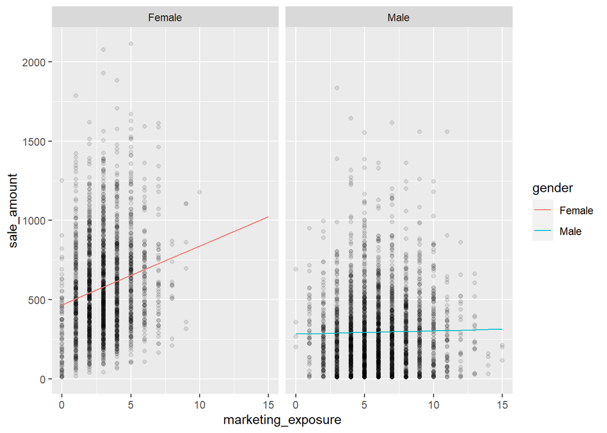

```r
## score data
new_df2 <-
  expand.grid(marketing_exposure = seq(0,15,1),
              gender=unique(sale_df_sub$gender))
new_df2$predicted_sale_amount <-
  predict(mod8,newdata = new_df2)
## make plot
ggplot(sale_df_sub,aes(x=marketing_exposure,y=sale_amount)) +
  geom_point(alpha=0.1) +
  facet_wrap(~gender) +
  geom_line(data=new_df2,aes(marketing_exposure,predicted_sale_amount,color=gender))
```

# Final model

As a final model, we may decide to include age and age squared as well:

```r
## fit model
mod8 <-
  lm(sale_amount ~ marketing_exposure*gender + age + I(age**2),
     data = sale_df_sub)
## check results
summary(mod8)
```

```
##
## Call:
## lm(formula = sale_amount ~ marketing_exposure * gender + age +
##     I(age^2), data = sale_df_sub)
##
## Residuals:
##     Min      1Q  Median      3Q     Max
## -736.91 -169.14  -36.69  124.35 1281.35
##
## Coefficients:
##                                 Estimate Std. Error t value Pr(>|t|)
## (Intercept)                   3025.60487   72.79121  41.566   <2e-16 ***
## marketing_exposure              33.09659    3.11903  10.611   <2e-16 ***
## genderMale                    -166.99725   16.43217 -10.163   <2e-16 ***
## age                            -89.17625    2.38442 -37.400   <2e-16 ***
## I(age^2)                         0.75036    0.01966  38.166   <2e-16 ***
## marketing_exposure:genderMale  -33.13575    3.63494  -9.116   <2e-16 ***
## ---
## Signif. codes:  0 '***' 0.001 '**' 0.01 '*' 0.05 '.' 0.1 ' ' 1
##
## Residual standard error: 237.3 on 4759 degrees of freedom
## Multiple R-squared:  0.4091, Adjusted R-squared:  0.4085
## F-statistic:   659 on 5 and 4759 DF,  p-value: < 2.2e-16
```

# Comparing model fits

How do we know which model is best?

- We can compare nested models using a likelihood ratio test.
- For models that are not nested, we must use a penalized likelihood statistic, like AIC. The lower the AIC, the better the model.

```r
## nested likelihood ratio test
anova(mod7,mod8)
```

```
## Analysis of Variance Table
##
## Model 1: sale_amount ~ marketing_exposure
## Model 2: sale_amount ~ marketing_exposure * gender + age + I(age^2)
##   Res.Df       RSS Df Sum of Sq      F    Pr(>F)
## 1   4763 437159471
## 2   4759 267984749  4 169174722 751.07 < 2.2e-16 ***
## ---
## Signif. codes:  0 '***' 0.001 '**' 0.01 '*' 0.05 '.' 0.1 ' ' 1
```

```r
## compare AIC
mod5$call
```

```
## lm(formula = sale_amount ~ age + I(age^2), data = sale_df_sub)
```

```r
mod7$call
```

```
## lm(formula = sale_amount ~ marketing_exposure, data = sale_df_sub)
```

```r
AIC(mod5,mod7)
```

```
##      df      AIC
## mod5  4 66821.45
## mod7  3 67976.98
```

# Conclusion

In this lecture you received an introduction and overview of linear models.

We covered the following topics:

- Connecting linear models to estimation of the mean
- Implementing single predictors
- Implementing multiple predictors
- Interpreting model output
- Continuous versus categorical predictors
- Exploring residuals
- Comparing models

Linear modeling techniques you just learned are the foundation of many parametric models. We will take this knowledge and apply it in future sections!